# pandas 연습문제

1. 딕셔너리를 이용하여 아래와 같은 모양이 되도록 data frame을 생성하시오.

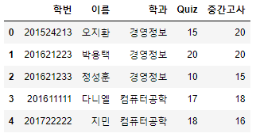

```python
import pandas as pd

score = {'학번':['201524213','201621223','201621233','201611111','201722222'],
        '이름':['오지환','박용택','정성훈','다니엘','지민'],
        '학과':['경영정보','경영정보','경영정보','컴퓨터공학','컴퓨터공학'],
        'Quiz':[15,20,10,17,18],
        '중간고사':[20,20,15,18,16]}
score_df = pd.DataFrame(score)
score_df
```

|  | 학번 | 이름 | 학과 | Quiz | 중간고사 |
| --- | --- | --- | --- | --- | --- |
| 0 | 201524213 | 오지환 | 경영정보 | 15 | 20 |
| 1 | 201621223 | 박용택 | 경영정보 | 20 | 20 |
| 2 | 201621233 | 정성훈 | 경영정보 | 10 | 15 |
| 3 | 201611111 | 다니엘 | 컴퓨터공학 | 17 | 18 |
| 4 | 201722222 | 지민 | 컴퓨터공학 | 18 | 16 |

1. 위에서 생성한 데이터프레임으로부터 인덱싱을 이용하여 이름과 중간고사를 추출하시오.

```python
score_df[['이름','중간고사']]
```

|  | 이름 | 중간고사 |
| --- | --- | --- |
| 0 | 오지환 | 20 |
| 1 | 박용택 | 20 |
| 2 | 정성훈 | 15 |
| 3 | 다니엘 | 18 |
| 4 | 지민 | 16 |

1. reindex를 이용하여 2, 0, 4, 1, 3 순으로 순서를 변경하시오.

```python
df = score_df.reindex([2,0,4,1,3])
df
```

|  | 학번 | 이름 | 학과 | Quiz | 중간고사 |
| --- | --- | --- | --- | --- | --- |
| 2 | 201621233 | 정성훈 | 경영정보 | 10 | 15 |
| 0 | 201524213 | 오지환 | 경영정보 | 15 | 20 |
| 4 | 201722222 | 지민 | 컴퓨터공학 | 18 | 16 |
| 1 | 201621223 | 박용택 | 경영정보 | 20 | 20 |
| 3 | 201611111 | 다니엘 | 컴퓨터공학 | 17 | 18 |

1. iloc과 loc을 각각 이용하여 박용택 학생의 record를 추출하시오. (iloc으로 한번, loc으로 한번 수행)

```python
df.loc[[1],:]
```

|  | 학번 | 이름 | 학과 | Quiz | 중간고사 |
| --- | --- | --- | --- | --- | --- |
| 1 | 201621223 | 박용택 | 경영정보 | 20 | 20 |

```python
df.iloc[[3],:]
```

|  | 학번 | 이름 | 학과 | Quiz | 중간고사 |
| --- | --- | --- | --- | --- | --- |
| 1 | 201621223 | 박용택 | 경영정보 | 20 | 20 |

1. iloc과 loc을 각각 이용하여 모든 학생의 이름과 중간고사 점수를 추출하시오. (iloc으로 한번, loc으로 한번 수행)

```python
df.loc[:, ['이름','중간고사']]
```

|  | 이름 | 중간고사 |
| --- | --- | --- |
| 2 | 정성훈 | 15 |
| 0 | 오지환 | 20 |
| 4 | 지민 | 16 |
| 1 | 박용택 | 20 |
| 3 | 다니엘 | 18 |

```python
df.iloc[:,[1,4]]
```

|  | 이름 | 중간고사 |
| --- | --- | --- |
| 2 | 정성훈 | 15 |
| 0 | 오지환 | 20 |
| 4 | 지민 | 16 |
| 1 | 박용택 | 20 |
| 3 | 다니엘 | 18 |

1. 중간고사 점수의 평균을 구하시오.

```python
df['중간고사'].mean()
```

```
17.8
```

1. 중간고사 점수가 가장 낮은 학생의 index를 구하시오.

```python
df.loc[df['중간고사'].idxmin()]
```

```
학번      201621233
이름            정성훈
학과           경영정보
Quiz           10
중간고사           15
Name: 2, dtype: object
```

1. 퀴즈 점수가 가장 높은 학생의 학번을 구하시오.

```python
df.loc[df['Quiz'].idxmax(),'학번']
```

```
'201621223'
```

1. 위 데이터프레임의 각 열에 대해서 개수, 평균, 표준편차, 최소최대값 등의 다양한 통계량을 출력하시오.

```python
df.describe()
```

|  | Quiz | 중간고사 |
| --- | --- | --- |
| count | 5.000000 | 5.000000 |
| mean | 16.000000 | 17.800000 |
| std | 3.807887 | 2.280351 |
| min | 10.000000 | 15.000000 |
| 25% | 15.000000 | 16.000000 |
| 50% | 17.000000 | 18.000000 |
| 75% | 18.000000 | 20.000000 |
| max | 20.000000 | 20.000000 |

1. 위 데이터프레임을 중간고사 점수에 따라 내림차순으로 정렬하시오.

```python
df.sort_values('중간고사', ascending=False)
```

|  | 학번 | 이름 | 학과 | Quiz | 중간고사 |
| --- | --- | --- | --- | --- | --- |
| 0 | 201524213 | 오지환 | 경영정보 | 15 | 20 |
| 1 | 201621223 | 박용택 | 경영정보 | 20 | 20 |
| 3 | 201611111 | 다니엘 | 컴퓨터공학 | 17 | 18 |
| 4 | 201722222 | 지민 | 컴퓨터공학 | 18 | 16 |
| 2 | 201621233 | 정성훈 | 경영정보 | 10 | 15 |

1. 학생 중에서 퀴즈 점수가 평균 이상인 학생들의 이름을 출력하시오.

```python
print(type(df['Quiz'] >= df['Quiz'].mean()))
(df['Quiz'] >= df['Quiz'].mean())
df[df['Quiz'] >= df['Quiz'].mean()]['이름']
```

```
<class 'pandas.core.series.Series'>
```

```
4     지민
1    박용택
3    다니엘
Name: 이름, dtype: object
```

1. 학생 중에서 퀴즈와 중간고사 점수 모두 평균 이상인 학생들의 record를 출력하시오.

```python
df[(df['Quiz'] >= df['Quiz'].mean()) & (df['중간고사'] >= df['중간고사'].mean())]
```

|  | 학번 | 이름 | 학과 | Quiz | 중간고사 |
| --- | --- | --- | --- | --- | --- |
| 1 | 201621223 | 박용택 | 경영정보 | 20 | 20 |
| 3 | 201611111 | 다니엘 | 컴퓨터공학 | 17 | 18 |

1. value_counts를 이용하여 학과 별로 학생의 수를 구하시오.

```python
df['학과'].value_counts()
```

```
경영정보     3
컴퓨터공학    2
Name: 학과, dtype: int64
```

1. groupby를 이용하여 학과 별로 중간고사의 평균을 구하시오.

```python
df.groupby('학과')['중간고사'].mean()
```

```
학과
경영정보     18.333333
컴퓨터공학    17.000000
Name: 중간고사, dtype: float64
```